# Clustering and enrichment analysis

Daven Lim

```r
suppressPackageStartupMessages({
  library(GenomicRanges)
  library(epiwraps)
  library(ggplot2)
  library(rGREAT) # Gene Ontology enrichment among genomic regions
  library(GenomeInfoDb)
})
```

## Download the data

```r
options(timeout = 6000)
download.file("https://ethz-ins.org/content/clustering_assignment.zip", "clustering_assignment.zip")
unzip("clustering_assignment.zip")
list.files()
```

## Prepare the regions and the tracks

```r
tracks <- list.files(pattern="bw$")
tracks
```

```
## [1] "Creb1.bw"   "Creb3.bw"   "Creb3L1.bw"
```

```r
# regions <- rtracklayer::import.bed("Creb3L1.bed")

peaks <- list.files(pattern="bed$")
peaks <- lapply(peaks, rtracklayer::import.bed)
peaks <- lapply(peaks, function(x) keepSeqlevels(x, "chr1", pruning.mode="coarse"))
peaks <- lapply(peaks, FUN=function(x) x[x$score>800])
regions <- reduce(unlist(GRangesList(peaks)))
regions <- keepSeqlevels(regions, "chr1", pruning.mode="coarse")
```

## Plot

```r
ese <- signal2Matrix(tracks, regions, extend=2000)
```

```
## Reading Creb1.bw
```

```
## Reading Creb3.bw
```

```
## Reading Creb3L1.bw
```

[output not shown]

[output not shown]

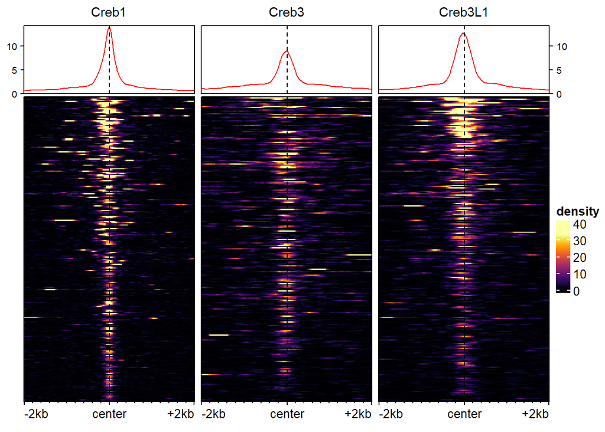

```r
plotEnrichedHeatmaps(ese)
```

[output not shown]

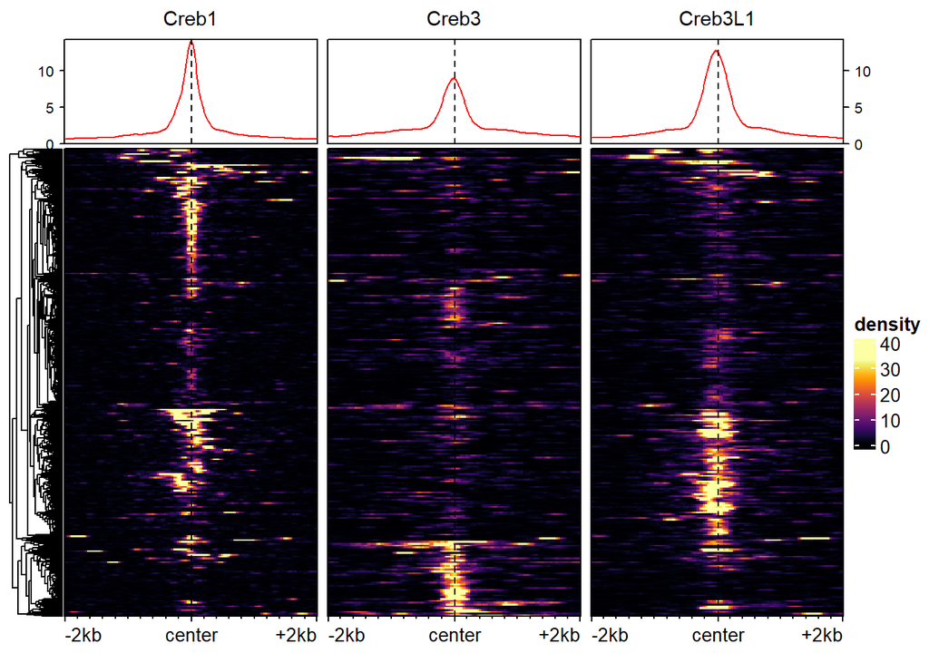

```r
# ese2 <- ese[1:1000,]
plotEnrichedHeatmaps(ese, cluster_rows = TRUE, show_row_dend=TRUE )
```

## Clustering

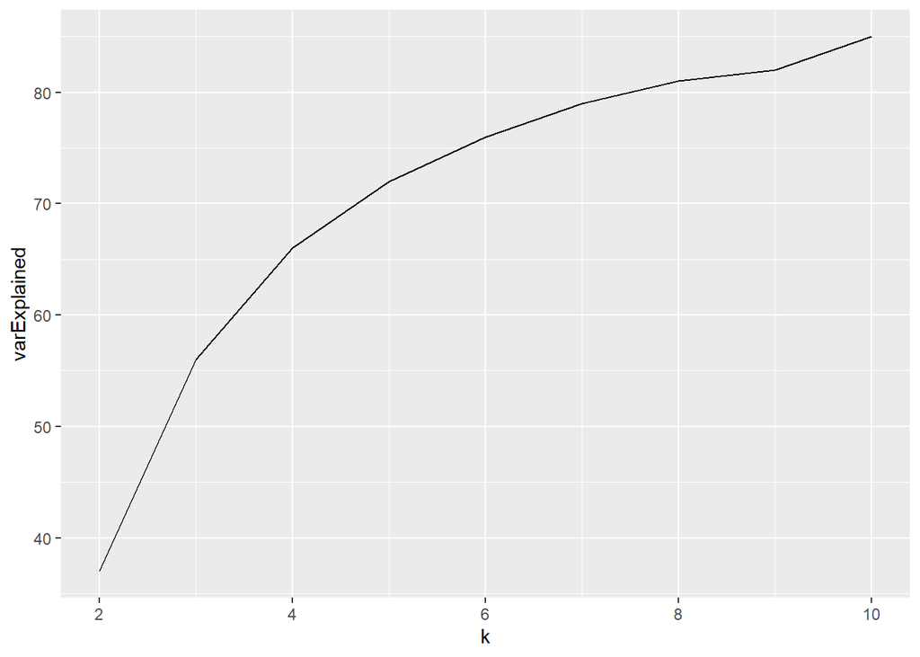

```r
cl2 <- clusterSignalMatrices(ese, k=2:10)
ggplot(cl2$varExplained, aes(k, varExplained)) + geom_line()
```

```r
set.seed(123)
cl <- clusterSignalMatrices(ese, k=3, scaleRows=TRUE)
```

```
##   ~80% of the variance explained by clusters
```

```r
table(cl)
```

```
## cl
##    1    2    3
##  413 1117  739
```

```r
head(cl)
```

```
## [1] 2 2 1 1 1 2
## Levels: 1 2 3
```

```r
length(cl)
```

```
## [1] 2269
```

```r
nrow(ese)
```

```
## [1] 2269
```

```r
rowData(ese)$cluster <- cl
head(rowData(ese))
```

```
## DataFrame with 6 rows and 1 column
##                     cluster
##                    <factor>
## chr1:778487-779069        2
## chr1:904436-904985        2
## chr1:941785-942096        1
## chr1:943126-943501        1
## chr1:959088-959463        1
## chr1:961148-961904        2
```

Plotting the clusters:

[output not shown]

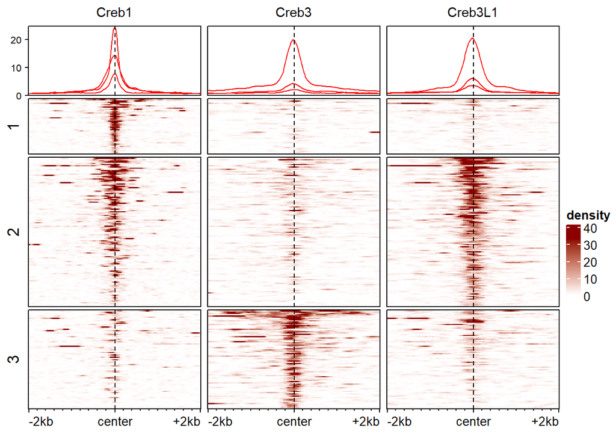

```r
#plotEnrichedHeatmaps(ese, row_split="cluster", colors=c("white","darkred"))
plotEnrichedHeatmaps(ese, row_split=rowData(ese)$cluster,
                     colors=c("white","darkred"))
```

Adding colors:

[output not shown]

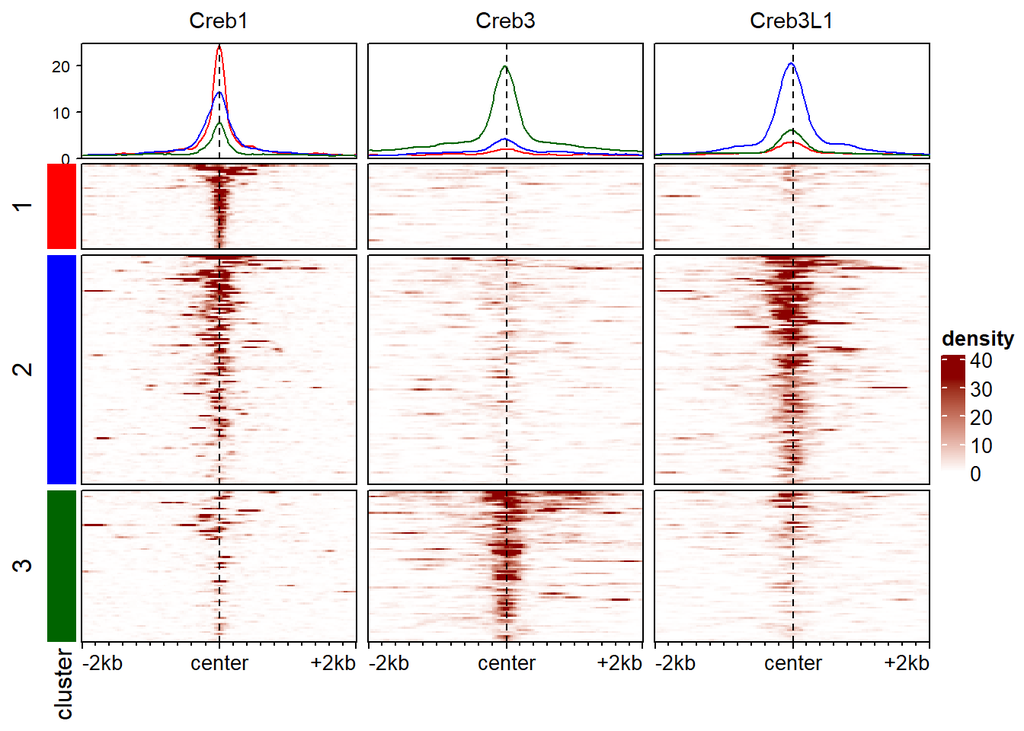

```r
mycolors <- c("1"="red", "2"="blue", "3"="darkgreen", "4"="black")
plotEnrichedHeatmaps(ese, row_split="cluster", mean_color=mycolors, colors=c("white","darkred"))
```

Plotting just the averages:

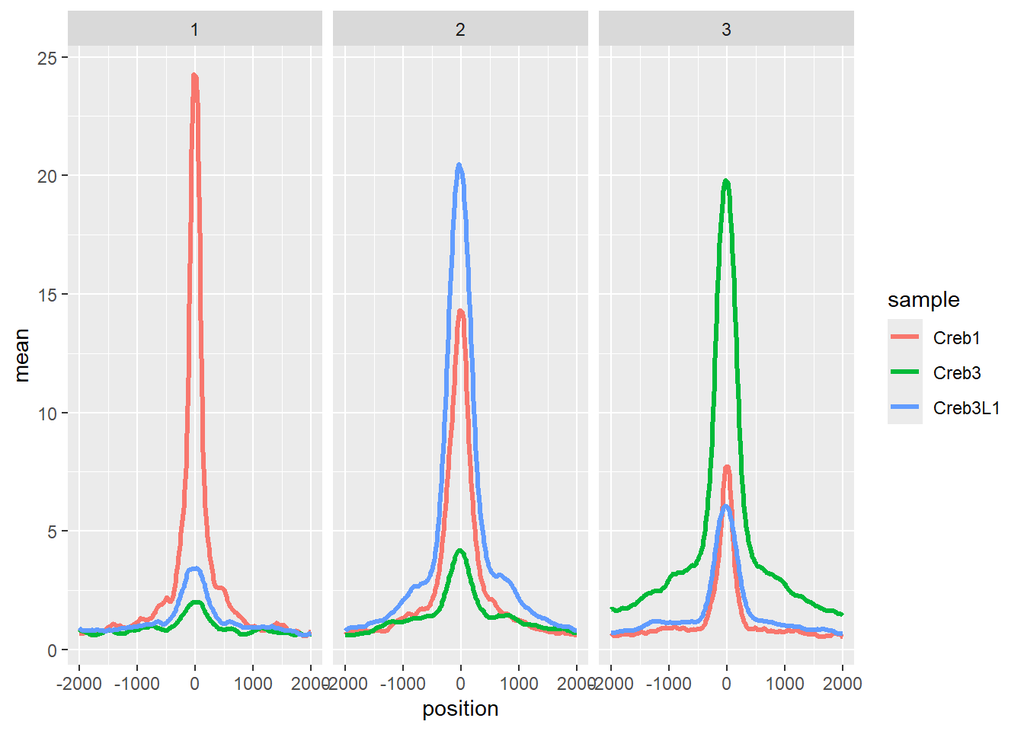

```r
d <- meltSignals(ese, splitBy=cl)
ggplot(d, aes(position, mean, colour=sample)) + geom_line(size=1.2) + facet_wrap(~split)
```

```r
set.seed(123)
cl <- clusterSignalMatrices(ese, k=3, scaleRows = TRUE)
```

```
##   ~80% of the variance explained by clusters
```

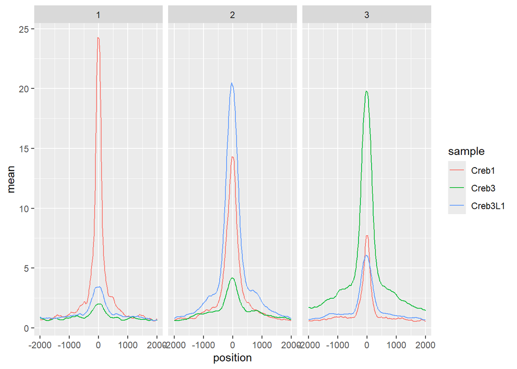

```r
d <- meltSignals(ese, splitBy=cl)
ggplot(d, aes(position, mean, colour=sample)) + geom_line() + facet_wrap(~split)
```

[output not shown]

[output not shown]

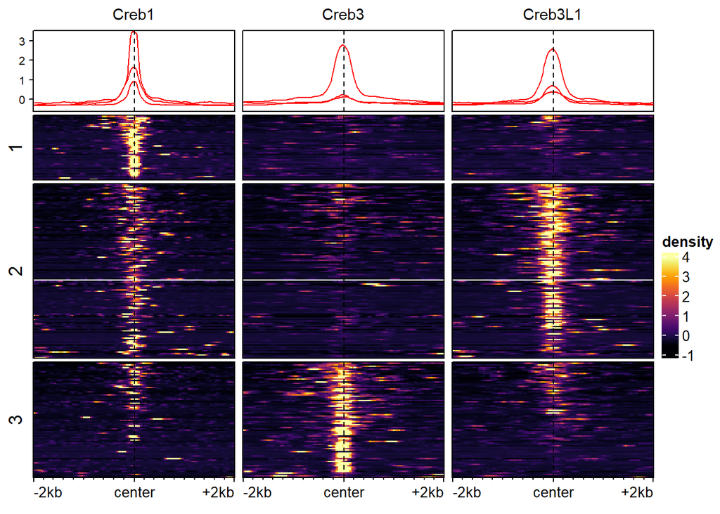

```r
plotEnrichedHeatmaps(ese, row_split = cl, scale_rows = "global")
```

## Enrichment analysis

Find what’s enriched in one cluster with respect to the others:

```r
split_regions <- split(rowRanges(ese), rowData(ese)$cluster)
lengths(split_regions)
```

```
##    1    2    3
##  413 1117  739
```

```r
res <- great(split_regions[["3"]], gene_sets="GO:BP", tss_source="hg38",
             background=regions, cores=2)
```

```
## * TSS source: TxDb.
```

```
## * check whether TxDb package 'TxDb.Hsapiens.UCSC.hg38.knownGene' is installed.
```

```
## * gene ID type in the extended TSS is 'Entrez Gene ID'.
```

```
## * restrict chromosomes to 'chr1, chr2, chr3, chr4, chr5, chr6, chr7, chr8, chr9, chr10,
##     chr11, chr12, chr13, chr14, chr15, chr16, chr17, chr18, chr19, chr20, chr21, chr22, chrX,
##     chrY, chrM'.
```

```
## * 18193/35161 protein-coding genes left.
```

```
## * update seqinfo to the selected chromosomes.
```

```
## * TSS extension mode is 'basalPlusExt'.
```

```
## * construct the basal domains by extending 5000bp to upstream and 1000bp to downsteram of TSS.
```

```
## * calculate distances to neighbour regions.
```

```
## * extend to both sides until reaching the neighbour genes or to the maximal extension.
```

```
## * use GO:BP ontology with 15046 gene sets (source: org.Hs.eg.db).
```

```
## * check gene ID type in `gene_sets` and in `extended_tss`.
```

```
## * use self-defined background regions.
```

```
## * remove excluded regions from background.
```

```
## * overlap `gr` to background regions (based on midpoint).
```

```
## * in total 739 `gr`.
```

```
## * overlap extended TSS to background regions.
```

```
## * check which genes are in the gene sets.
```

```
## * only take gene sets with size >= 5.
```

```
## * in total 2479 gene sets.
```

```
## * overlap `gr` to every extended TSS.
```

```
## * perform binomial test for each biological term.
```

```r
bp <- getEnrichmentTables(res)
head(bp)
```

```
##           id                      description genome_fraction
## 1 GO:0051716    cellular response to stimulus       0.5728734
## 2 GO:0001775                  cell activation       0.1321753
## 3 GO:0045321             leukocyte activation       0.1274130
## 4 GO:0032501 multicellular organismal process       0.5735694
## 5 GO:0002376            immune system process       0.2576506
## 6 GO:0007154               cell communication       0.5069115
##   observed_region_hits fold_enrichment      p_value     p_adjust mean_tss_dist
## 1                  498        1.176322 1.146858e-08 9.706280e-06        115780
## 2                  153        1.566378 1.170371e-08 9.706280e-06        112433
## 3                  148        1.571823 1.755720e-08 9.706280e-06        114610
## 4                  497        1.172535 2.202768e-08 9.706280e-06        115377
## 5                  258        1.355015 2.274199e-08 9.706280e-06        111478
## 6                  444        1.185240 1.813615e-07 5.189503e-05        119503
##   observed_gene_hits gene_set_size fold_enrichment_hyper p_value_hyper
## 1                303           543              1.145827  1.361389e-05
## 2                 61            88              1.423388  4.346048e-05
## 3                 57            82              1.427372  6.977591e-05
## 4                301           551              1.121737  2.034291e-04
## 5                118           204              1.187758  2.923564e-03
## 6                273           483              1.160624  1.277801e-05
##   p_adjust_hyper
## 1    0.003103765
## 2    0.004733162
## 3    0.005726992
## 4    0.009236546
## 5    0.052445392
## 6    0.003103765
```

We plot the top Biological Processes:

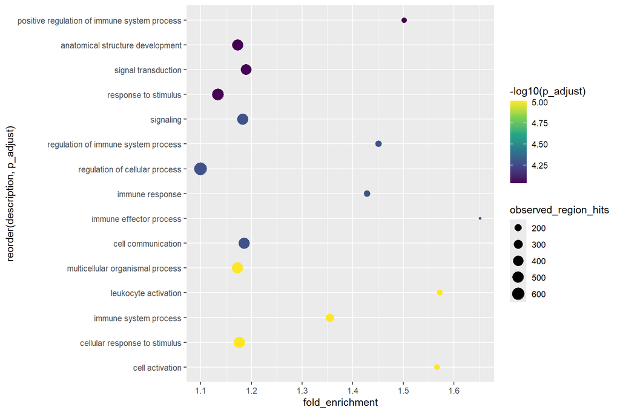

```r
ggplot(head(bp,15), aes(fold_enrichment, reorder(description, p_adjust),
                        size=observed_region_hits, color=-log10(p_adjust))) +
  geom_point() + scale_color_viridis_c()
```

Clustering analysis on CREB-family binding regions on chromosome 1 revealed occupancy patterns across the three transcription factors. The heatmaps and signal profile plots showed subsets of regions that exhibited stronger enrichment for specific factors, indicating specific binding behavior. K-means clustering separated the regions into groups with different binding intensities, with the number of clusters selected based on the variance-explained plot (three clusters), suggesting functional specialization among the CREB family proteins. Gene Ontology enrichment analysis of one cluster identified significant enrichment for immune-related biological processes, including immune system process, leukocyte activation, immune effector process, and cell activation. Additional enrichment was also observed for signaling and cellular response pathways. This suggests that this cluster may represent regulatory regions involved in immune signaling and cellular communication, and a possible role for CREB-family transcription factors in controlling immune-associated gene regulation.